# Conceptual part

### A.1.

**Correct answer:** ii. For a fixed value of IQ and GPA, college graduates earn more, on average, than high school graduates.

**Reason:** There are no further information about how the interactions (i.e. $X4$ and $X5$) does look like. So I have to assume something:

Looking at question 3 I assume $X4=\frac{X1}{X2}$. Since $X3 \in [0,1]$, I would not assume $X5=\frac{X1}{X3}$, because this could end in an devision by zero. Therefore I assume it the other way around, i.e. $X5=\frac{X3}{X1}$, (assuming that there is no data with a GPA < 2.0, because otherwise they would have been no graduates).

Since GPA (X1) and IQ (X2) are fixed, X4 is also fixed. So the statement depends on X3 and X5, which means that we have show that there is a minimal value for $X1 \geq 2.0$ so that the part of the estimatied function containing the relevant predictors in our case, i.e. X3 and X5, is greater than 0: $$ \hat{\beta}_3*X3 + \hat{\beta}_5\frac{X3}{X1} > 0 \text{ | insert slopes and predictors} \\ 35*1-10\frac{1}{X1} > 0 \text{ | } +\frac{10}{X1} \\ 35 > \frac{10}{X1} \text{ | } * X1 \\ 35X1 > 10 \text{ | } / 35 \\ X1 > \frac{10}{35} $$ So the minimal value for the GPA would be $\frac{10}{35}=0.29$. But considering the domain here, it is impossible to graduate with a GPA < 2.0. So a college graduate is estimated to earn more than a high school graduate either way. (based on my assumptions above)

### A.2.

$$ \hat{y} = \hat{\beta}_0 + \hat{\beta}_1X1 + \hat{\beta}_2X2 + \hat{\beta}_3X3 + \hat{\beta}_4X4 + \hat{\beta}_5X5 \text{ | insert estimated interception and slope} \\ \hat{y} = 50 + 20X1 + 0.07X2 + 35X3 + 0.01X4 + (-10)X5 \text{ | insert predictor values, with } X4=\frac{X1}{X2} \text{ and } X5=\frac{X3}{X1} \\ \hat{y} = 50 + 20*4.0 + 0.07*110 + 35*1 + 0.01*\frac{4.0}{110} -10 *\frac{1}{4.0} \text{ | calculate} \\ \hat{y} = 170.204 $$ So the predicted salary for the given predictors is 170204$ (based on my assumptions from A.1.).

### A.3.

**False:** The (regression) coefficient was estimated for the estimation of a function that estimates the salary based on specific data. It does not tell anything about the interaction/correlation between the predictors used in this estimation, even if it is very small. If we want to find evidence for the interaction between two predictors, we need to consider the correletion coefficient of the two predictors (i.e. GPA and IQ). Even a look at the t-statistic and the p-value would give only information about the dependency between the interaction of the predictors itself and the estimated outcome of the estimates function, but not about the interaction between theses predictors.

# Practical part

## I: Load the data and get an overview of the data

```python
import pandas

df = pandas.read_csv('/media/home/ngundermann/workspace/MachineLearning/data/ISLR/data/Boston.csv', index_col=0)
```

I: Display the number of predictors (including the response medv ) and their names

```python
print(f'size: {len(df.columns.values)}')
print(f'columns: {df.columns.values}')
```

```
size: 14
columns: ['crim' 'zn' 'indus' 'chas' 'nox' 'rm' 'age' 'dis' 'rad' 'tax' 'ptratio'
 'black' 'lstat' 'medv']
```

I: Print a statistic summary of the predictors and the response medv

```python
for column in df.columns.values:
    print(f'{df[column].describe()}\n')
```

```
count    506.000000
mean       3.613524
std        8.601545
min        0.006320
25%        0.082045
50%        0.256510
75%        3.677083
max       88.976200
Name: crim, dtype: float64

count    506.000000
mean      11.363636
std       23.322453
min        0.000000
25%        0.000000
50%        0.000000
75%       12.500000
max      100.000000
Name: zn, dtype: float64

count    506.000000
mean      11.136779
std        6.860353
min        0.460000
25%        5.190000
50%        9.690000
75%       18.100000
max       27.740000
Name: indus, dtype: float64

count    506.000000
mean       0.069170
std        0.253994
min        0.000000
25%        0.000000
50%        0.000000
75%        0.000000
max        1.000000
Name: chas, dtype: float64

```

[output cut: 84 more lines]

```
25%        6.950000
50%       11.360000
75%       16.955000
max       37.970000
Name: lstat, dtype: float64

count    506.000000
mean      22.532806
std        9.197104
min        5.000000
25%       17.025000
50%       21.200000
75%       25.000000
max       50.000000
Name: medv, dtype: float64
```

I: Display the number of data points

```python
print(len(df))
```

```
506
```

I: Display the data in a table (subset of rows is sufficient)

```python
df
```

|  | crim | zn | indus | chas | nox | rm | age | dis | rad | tax | ptratio | black | lstat | medv |
| --- | --- | --- | --- | --- | --- | --- | --- | --- | --- | --- | --- | --- | --- | --- |
| 1 | 0.00632 | 18.0 | 2.31 | 0 | 0.538 | 6.575 | 65.2 | 4.0900 | 1 | 296 | 15.3 | 396.90 | 4.98 | 24.0 |
| 2 | 0.02731 | 0.0 | 7.07 | 0 | 0.469 | 6.421 | 78.9 | 4.9671 | 2 | 242 | 17.8 | 396.90 | 9.14 | 21.6 |
| 3 | 0.02729 | 0.0 | 7.07 | 0 | 0.469 | 7.185 | 61.1 | 4.9671 | 2 | 242 | 17.8 | 392.83 | 4.03 | 34.7 |
| 4 | 0.03237 | 0.0 | 2.18 | 0 | 0.458 | 6.998 | 45.8 | 6.0622 | 3 | 222 | 18.7 | 394.63 | 2.94 | 33.4 |
| 5 | 0.06905 | 0.0 | 2.18 | 0 | 0.458 | 7.147 | 54.2 | 6.0622 | 3 | 222 | 18.7 | 396.90 | 5.33 | 36.2 |
| ... | ... | ... | ... | ... | ... | ... | ... | ... | ... | ... | ... | ... | ... | ... |
| 502 | 0.06263 | 0.0 | 11.93 | 0 | 0.573 | 6.593 | 69.1 | 2.4786 | 1 | 273 | 21.0 | 391.99 | 9.67 | 22.4 |
| 503 | 0.04527 | 0.0 | 11.93 | 0 | 0.573 | 6.120 | 76.7 | 2.2875 | 1 | 273 | 21.0 | 396.90 | 9.08 | 20.6 |
| 504 | 0.06076 | 0.0 | 11.93 | 0 | 0.573 | 6.976 | 91.0 | 2.1675 | 1 | 273 | 21.0 | 396.90 | 5.64 | 23.9 |
| 505 | 0.10959 | 0.0 | 11.93 | 0 | 0.573 | 6.794 | 89.3 | 2.3889 | 1 | 273 | 21.0 | 393.45 | 6.48 | 22.0 |
| 506 | 0.04741 | 0.0 | 11.93 | 0 | 0.573 | 6.030 | 80.8 | 2.5050 | 1 | 273 | 21.0 | 396.90 | 7.88 | 11.9 |

506 rows × 14 columns

I: Plot some predictors (at least two) against the response values

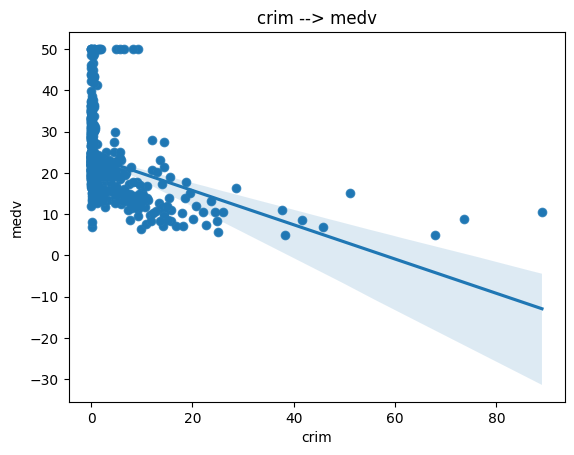

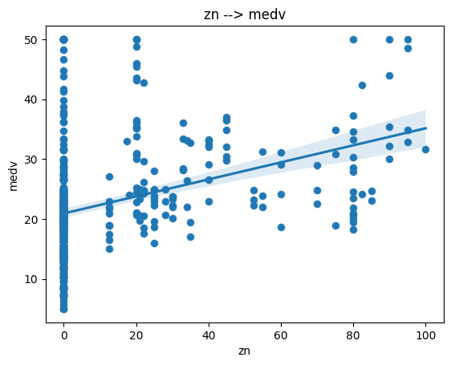

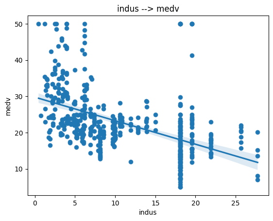

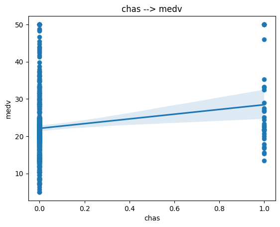

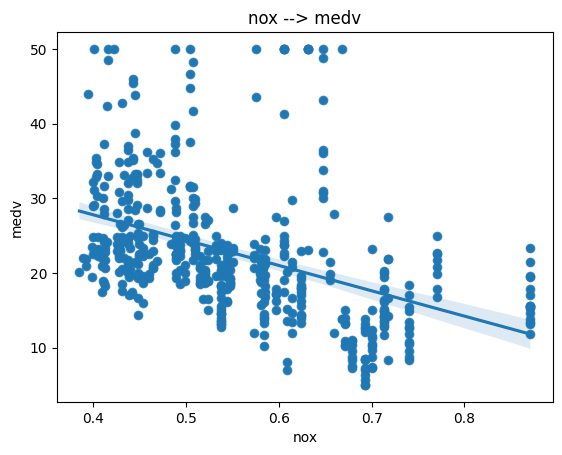

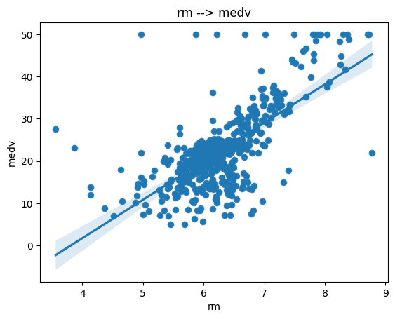

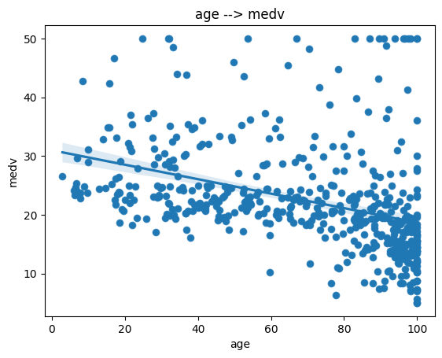

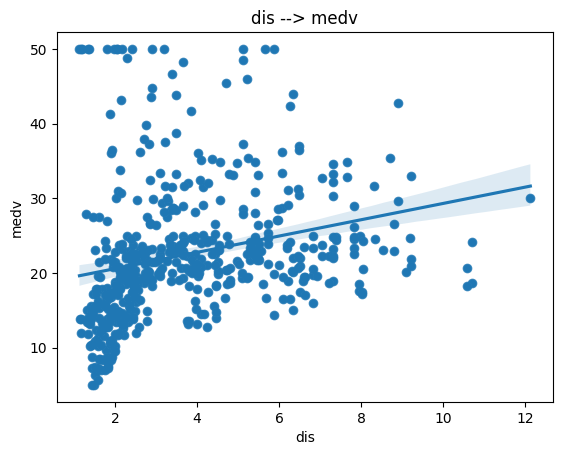

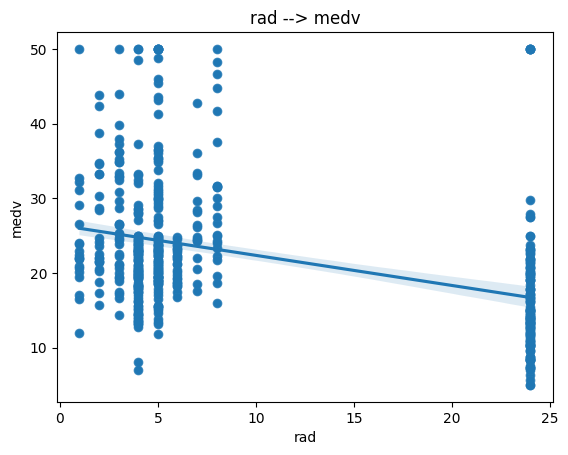

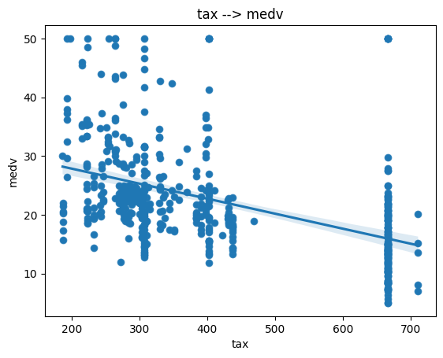

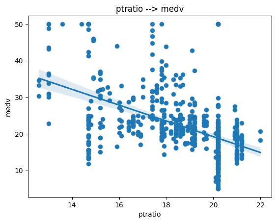

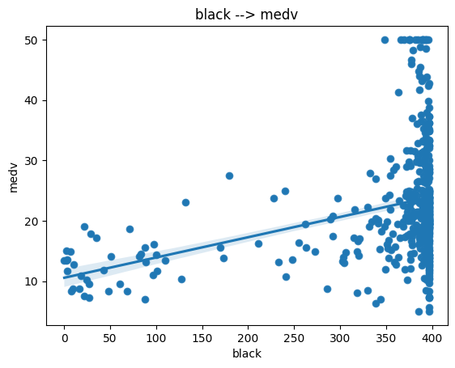

[1 more figures not shown]

```python
import matplotlib.pyplot as plt
import seaborn as sns


for feature in df.columns[df.columns != 'medv'].values:
    sns.scatterplot(df, x=feature, y='medv')
    sns.regplot(df, x=feature, y='medv',)
    plt.title(f'{feature} --> medv')
    plt.show()
```

## I: Perform simple linear regressions

I: Fit a simple linear regression model, with medv as the response and some (at least two) predictors individually

```python
import statsmodels.api as sm
import numpy as np

for feature in df.columns[df.columns != 'medv'].values[0:3]:
    print(f'FEATURE: {feature}')
    X = pandas.DataFrame({'intercept':np.ones(df.shape[0]),
                          feature:df[feature]})
    y = df['medv']
    lm = sm.OLS(y, X).fit()
    print(lm.summary())
```

```
FEATURE: crim
                            OLS Regression Results
==============================================================================
Dep. Variable:                   medv   R-squared:                       0.151
Model:                            OLS   Adj. R-squared:                  0.149
Method:                 Least Squares   F-statistic:                     89.49
Date:                Sat, 27 Jan 2024   Prob (F-statistic):           1.17e-19
Time:                        11:37:40   Log-Likelihood:                -1798.9
No. Observations:                 506   AIC:                             3602.
Df Residuals:                     504   BIC:                             3610.
Df Model:                           1
Covariance Type:            nonrobust
==============================================================================
                 coef    std err          t      P>|t|      [0.025      0.975]
------------------------------------------------------------------------------
intercept     24.0331      0.409     58.740      0.000      23.229      24.837
crim          -0.4152      0.044     -9.460      0.000      -0.501      -0.329
==============================================================================
Omnibus:                      139.832   Durbin-Watson:                   0.713
Prob(Omnibus):                  0.000   Jarque-Bera (JB):              295.404
Skew:                           1.490   Prob(JB):                     7.14e-65
Kurtosis:                       5.264   Cond. No.                         10.1
==============================================================================

Notes:
[1] Standard Errors assume that the covariance matrix of the errors is correctly specified.
FEATURE: zn
                            OLS Regression Results
==============================================================================
Dep. Variable:                   medv   R-squared:                       0.130
Model:                            OLS   Adj. R-squared:                  0.128
Method:                 Least Squares   F-statistic:                     75.26
Date:                Sat, 27 Jan 2024   Prob (F-statistic):           5.71e-17
Time:                        11:37:40   Log-Likelihood:                -1805.0
No. Observations:                 506   AIC:                             3614.
Df Residuals:                     504   BIC:                             3623.
Df Model:                           1
Covariance Type:            nonrobust
==============================================================================
                 coef    std err          t      P>|t|      [0.025      0.975]
```

[output cut: 23 more lines]

```
Covariance Type:            nonrobust
==============================================================================
                 coef    std err          t      P>|t|      [0.025      0.975]
------------------------------------------------------------------------------
intercept     29.7549      0.683     43.537      0.000      28.412      31.098
indus         -0.6485      0.052    -12.408      0.000      -0.751      -0.546
==============================================================================
Omnibus:                      178.432   Durbin-Watson:                   0.676
Prob(Omnibus):                  0.000   Jarque-Bera (JB):              562.993
Skew:                           1.672   Prob(JB):                    5.59e-123
Kurtosis:                       6.939   Cond. No.                         25.1
==============================================================================

Notes:
[1] Standard Errors assume that the covariance matrix of the errors is correctly specified.
```

I: Interprete the results.

**Predictor: crim**

The statistics of the simple linear regression with the predictor crim shows that there is a relationship between the predictor and the result medv, since the p values are below 5%. So there is evidence that the coefficient of the predictor as well as the interceptor is not zero. Anyway, the choosen predictor describes the changes in medv not that much, since $R^2 = 0.15$, which is not very high. But anyway it seem to be useful, since the F-statistics is greater that 1.

**Predictor: zn**

The statistics of the simple linear regression with the predictor zn shows that there is a relationship between the predictor and the result medv, since the p values are below 5%. So there is evidence that the coefficient of the predictor as well as the interceptor is not zero. Anyway, the choosen predictor describes the changes in medv not that much, since $R^2 = 0.13$, which is not very high. But anyway it seem to be useful, since the F-statistics is greater that 1.

**Predictor: indus**

The statistics of the simple linear regression with the predictor indus shows that there is a relationship between the predictor and the result medv, since the p values are below 5%. So there is evidence that the coefficient of the predictor as well as the interceptor is not zero. Anyway, the choosen predictor describes the changes in medv not that much, since $R^2 = 0.23$, which is not very high (but better that for the other predictors investigated). But anyway it seem to be useful, since the F-statistics is greater that 1.

I: Obtain a confidence interval for the coefficient estimates for the individual models.

This was aldready done by the code I used above. So I go right to the interpretation...

I: Interprete the results

**Predictor: crim**

The confidence intervall ranges from 23.229 to 24.837 for the intercept and from -0.501 to -0.329 for the slope. So we can assume (even assuming a normal distribution, which is the best we can do - anyway the central limit theorem kicks in here, since there are more than 30 datapoint) that the estimated linear function giving medv based on the single predictor (here crim) is likely to be: $\hat{f}(crim) = m*crim + n$, with $n \in [23.229,24.837]$ and $m \in [-0.501, -0.329]$. And this holds for 95% of all possible data.

**Predictor: zn**

The confidence intervall ranges from 20.083 to 21.752 for the intercept and from 0.110 to 0.174 for the slope. So we can assume (even assuming a normal distribution, which is the best we can do - anyway the central limit theorem kicks in here, since there are more than 30 datapoint) that the estimated linear function giving medv based on the single predictor (here zn) is likely to be: $\hat{f}(zn) = m*zn + n$, with $n \in [20.083,21.752]$ and $m \in [0.110, 0.174]$. And this holds for 95% of all possible data.

**Predictor: indus**

The confidence intervall ranges from 28.412 to 31.098 for the intercept and from -0.751 to -0.546 for the slope. So we can assume (even assuming a normal distribution, which is the best we can do - anyway the central limit theorem kicks in here, since there are more than 30 datapoint) that the estimated linear function giving medv based on the single predictor (here indus) is likely to be: $\hat{f}(indus) = m*indus + n$, with $n \in [28.412,31.098]$ and $m \in [-0.751, -0.546]$. And this holds for 95% of all possible data.

### I: Use the simple linear regression models

I: Predict the medv response values for some selected predictor values. Calculate the prediction intervals for these values

```python
for feature in df.columns[df.columns != 'medv'].values[0:3]:
    print(f'FEATURE: {feature}')
    X = pandas.DataFrame({'intercept':np.ones(df.shape[0]),
                          feature:df[feature]})
    y = df['medv']
    lm = sm.OLS(y, X).fit()
    pred = lm.get_prediction(pandas.DataFrame({'intercept':np.ones(3),
                                               feature :[0,5,10] }))
    confi = pred.conf_int(obs=False, alpha=0.05)
    print(f'Confidence-Intervalls:')
    print(f'fit\t\t\tlow\t\t\thigh')
    for v_idx in range(len(pred.predicted_mean)):
        print(f'{pred.predicted_mean[v_idx]}\t{confi[v_idx][0]}\t{confi[v_idx][1]}')

    predi = pred.conf_int(obs=True, alpha=0.05)
    print(f'Prediction-Intervalls:')
    print(f'fit\t\t\tlow\t\t\thigh')
    for v_idx in range(len(pred.predicted_mean)):
        print(f'{pred.predicted_mean[v_idx]}\t{predi[v_idx][0]}\t{predi[v_idx][1]}')
    print('\n')
```

```
FEATURE: crim
Confidence-Intervalls:
fit			low			high
24.033106174123873	23.229272330443624	24.83694001780412
21.95715478454842	21.20658812173191	22.707721447364925
19.881203394972964	18.95798188428357	20.80442490566236
Prediction-Intervalls:
fit			low			high
24.033106174123873	7.345723607505825	40.72048874074192
21.95715478454842	5.272253274747598	38.64205629434924
19.881203394972964	3.1876439772148153	36.57476281273111


FEATURE: zn
Confidence-Intervalls:
fit			low			high
20.91757911779982	20.083099032630532	21.75205920296911
21.628279088576594	20.85077850053445	22.40577967661874
22.338979059353367	21.587666839890083	23.09029127881665
Prediction-Intervalls:
fit			low			high
20.91757911779982	4.025475003397624	37.80968323220202
21.628279088576594	4.7388939143417055	38.51766426281148
22.338979059353367	5.450779201157282	39.22717891754945


FEATURE: indus
Confidence-Intervalls:
fit			low			high
29.754896511928507	28.412143984359272	31.097649039497743
26.51244624384993	25.567809520168176	27.457082967531683
23.26999597577135	22.556635344219334	23.98335660732337
Prediction-Intervalls:
fit			low			high
29.754896511928507	13.867683936786282	45.642109087070736
26.51244624384993	10.653919275773989	42.37097321192587
23.26999597577135	7.423563492461048	39.116428459081654
```

I: Interprete the results

The predction intevalls indicates how close the predicted value will be to the real value, considering the reducable error (coming from the bias of the fitted function) as well as the irreducable error (coming from the real world problem, we can not handle). All of the prediction intervalls are quite wide (as much wider than the confidence intervalls), which is likely to be the case, because prediction intervalls are wide than confidence intervals. But according to the predictor values I used, one can be sure that the real value is likely to be in the plotted low and high values, with a mean of the value in the fit column, in approx. 95% of all cases.

### I: Perform multiple linear regressions

Fit medv as response with the predictors selected before altogether

```python
from ISLP.models import ModelSpec as MS

X = MS(df.columns[0:3]).fit_transform(df)
y = df['medv']
lm = sm.OLS(y,X).fit()
print(lm.summary())
```

```
                            OLS Regression Results
==============================================================================
Dep. Variable:                   medv   R-squared:                       0.294
Model:                            OLS   Adj. R-squared:                  0.289
Method:                 Least Squares   F-statistic:                     69.59
Date:                Sat, 27 Jan 2024   Prob (F-statistic):           1.21e-37
Time:                        11:57:54   Log-Likelihood:                -1752.3
No. Observations:                 506   AIC:                             3513.
Df Residuals:                     502   BIC:                             3529.
Df Model:                           3
Covariance Type:            nonrobust
==============================================================================
                 coef    std err          t      P>|t|      [0.025      0.975]
------------------------------------------------------------------------------
intercept     27.3946      0.865     31.676      0.000      25.695      29.094
crim          -0.2486      0.044     -5.662      0.000      -0.335      -0.162
zn             0.0585      0.017      3.344      0.001       0.024       0.093
indus         -0.4156      0.064     -6.515      0.000      -0.541      -0.290
==============================================================================
Omnibus:                      197.887   Durbin-Watson:                   0.754
Prob(Omnibus):                  0.000   Jarque-Bera (JB):              694.740
Skew:                           1.824   Prob(JB):                    1.38e-151
Kurtosis:                       7.432   Cond. No.                         65.4
==============================================================================

Notes:
[1] Standard Errors assume that the covariance matrix of the errors is correctly specified.
```

I: Interprete the results

The overall accuracy of the model, measured by the $R^2=0.294$ is better than the accuary of the models fitted for simple linear regression, but anyway not very good. All coefficients seem to be not zero and helpful to the estimation, since the p-values of the t-statistics are below 5% and the F-statistics is greater thatn 1.

I: Fit medv as response with all available predictors altogether.

```python
X = MS(df.columns[:-1]).fit_transform(df)
y = df['medv']
lm = sm.OLS(y,X).fit()
print(lm.summary())
```

```
                            OLS Regression Results
==============================================================================
Dep. Variable:                   medv   R-squared:                       0.741
Model:                            OLS   Adj. R-squared:                  0.734
Method:                 Least Squares   F-statistic:                     108.1
Date:                Sat, 27 Jan 2024   Prob (F-statistic):          6.72e-135
Time:                        12:00:17   Log-Likelihood:                -1498.8
No. Observations:                 506   AIC:                             3026.
Df Residuals:                     492   BIC:                             3085.
Df Model:                          13
Covariance Type:            nonrobust
==============================================================================
                 coef    std err          t      P>|t|      [0.025      0.975]
------------------------------------------------------------------------------
intercept     36.4595      5.103      7.144      0.000      26.432      46.487
crim          -0.1080      0.033     -3.287      0.001      -0.173      -0.043
zn             0.0464      0.014      3.382      0.001       0.019       0.073
indus          0.0206      0.061      0.334      0.738      -0.100       0.141
chas           2.6867      0.862      3.118      0.002       0.994       4.380
nox          -17.7666      3.820     -4.651      0.000     -25.272     -10.262
rm             3.8099      0.418      9.116      0.000       2.989       4.631
age            0.0007      0.013      0.052      0.958      -0.025       0.027
dis           -1.4756      0.199     -7.398      0.000      -1.867      -1.084
rad            0.3060      0.066      4.613      0.000       0.176       0.436
tax           -0.0123      0.004     -3.280      0.001      -0.020      -0.005
ptratio       -0.9527      0.131     -7.283      0.000      -1.210      -0.696
black          0.0093      0.003      3.467      0.001       0.004       0.015
lstat         -0.5248      0.051    -10.347      0.000      -0.624      -0.425
==============================================================================
Omnibus:                      178.041   Durbin-Watson:                   1.078
Prob(Omnibus):                  0.000   Jarque-Bera (JB):              783.126
Skew:                           1.521   Prob(JB):                    8.84e-171
Kurtosis:                       8.281   Cond. No.                     1.51e+04
==============================================================================

Notes:
[1] Standard Errors assume that the covariance matrix of the errors is correctly specified.
[2] The condition number is large, 1.51e+04. This might indicate that there are
strong multicollinearity or other numerical problems.
```

I: Interprete the result

It looks like there are almost all predictions reasonalbe to use for the prediciton of medv. Only two possible predictors came with a p-value > 5% in this model, i.e. indus and age. That means that the coefficients of these two predictors are close to zero. This is very interesting, because indus was not indicated as a that much worse predictor compared th crim or zn according to the simple linear regression model (indeed indus was the best predictor of these three according to the R2-score). So it seems that indus is related to some other of the possible predictors.

Anyway the overall accuracy of this model is much better, since $R^2=0.74$.

I: Check the correlation between the predictors

```
             crim        zn     indus      chas       nox        rm       age  \
crim     1.000000 -0.200469  0.406583 -0.055892  0.420972 -0.219247  0.352734
zn      -0.200469  1.000000 -0.533828 -0.042697 -0.516604  0.311991 -0.569537
indus    0.406583 -0.533828  1.000000  0.062938  0.763651 -0.391676  0.644779
chas    -0.055892 -0.042697  0.062938  1.000000  0.091203  0.091251  0.086518
nox      0.420972 -0.516604  0.763651  0.091203  1.000000 -0.302188  0.731470
rm      -0.219247  0.311991 -0.391676  0.091251 -0.302188  1.000000 -0.240265
age      0.352734 -0.569537  0.644779  0.086518  0.731470 -0.240265  1.000000
dis     -0.379670  0.664408 -0.708027 -0.099176 -0.769230  0.205246 -0.747881
rad      0.625505 -0.311948  0.595129 -0.007368  0.611441 -0.209847  0.456022
tax      0.582764 -0.314563  0.720760 -0.035587  0.668023 -0.292048  0.506456
ptratio  0.289946 -0.391679  0.383248 -0.121515  0.188933 -0.355501  0.261515
black   -0.385064  0.175520 -0.356977  0.048788 -0.380051  0.128069 -0.273534
lstat    0.455621 -0.412995  0.603800 -0.053929  0.590879 -0.613808  0.602339

              dis       rad       tax   ptratio     black     lstat
crim    -0.379670  0.625505  0.582764  0.289946 -0.385064  0.455621
zn       0.664408 -0.311948 -0.314563 -0.391679  0.175520 -0.412995
indus   -0.708027  0.595129  0.720760  0.383248 -0.356977  0.603800
chas    -0.099176 -0.007368 -0.035587 -0.121515  0.048788 -0.053929
nox     -0.769230  0.611441  0.668023  0.188933 -0.380051  0.590879
rm       0.205246 -0.209847 -0.292048 -0.355501  0.128069 -0.613808
age     -0.747881  0.456022  0.506456  0.261515 -0.273534  0.602339
dis      1.000000 -0.494588 -0.534432 -0.232471  0.291512 -0.496996
rad     -0.494588  1.000000  0.910228  0.464741 -0.444413  0.488676
tax     -0.534432  0.910228  1.000000  0.460853 -0.441808  0.543993
ptratio -0.232471  0.464741  0.460853  1.000000 -0.177383  0.374044
black    0.291512 -0.444413 -0.441808 -0.177383  1.000000 -0.366087
lstat   -0.496996  0.488676  0.543993  0.374044 -0.366087  1.000000
```

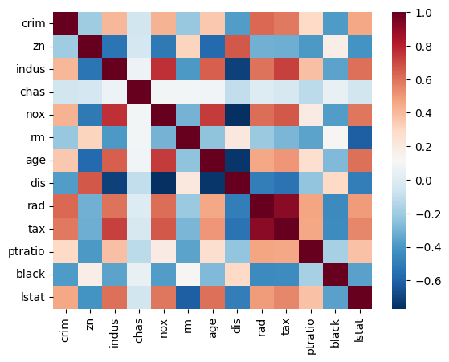

```python
print(df[df.columns[df.columns != 'medv']].corr(method='pearson'))
sns.heatmap(df[df.columns[df.columns != 'medv']].corr(method='pearson'), cmap='RdBu_r')
plt.show()
```

I: Interprete the results

There is just one predictor that shows a weak correleation to all the other predictors in general, i.e. chas.

The predictors rad and tax show a very strong positive correlation (0.91). The predictors that might be irrelevant for the multilinear model, i.e. age and indus, are strong positive correlated (0.73 and 0.76) to the nox predictor. Additionally they are strong negatively (-0.71 and -0.75) correlated to the dis predictor. This also hold for the nox predictor (-0.77). Maybe the irrelevance of indus and age in the fitted multilinear model is based on that correlations.

### I: Use the multiple linear regression model

I: Select some predictor values

```python
from itertools import product

lstat_values = [5,10,15]
rm_values = [5,6.5,8]
pred_values = pandas.DataFrame(data={'lstat':[5,10,15],
                                     'rm':[5,6.5,8]})

combis = list(product(lstat_values, rm_values))

pred_values = pandas.DataFrame(combis, columns=['lstat', 'rm'])
pred_values
```

|  | lstat | rm |
| --- | --- | --- |
| 0 | 5 | 5.0 |
| 1 | 5 | 6.5 |
| 2 | 5 | 8.0 |
| 3 | 10 | 5.0 |
| 4 | 10 | 6.5 |
| 5 | 10 | 8.0 |
| 6 | 15 | 5.0 |
| 7 | 15 | 6.5 |
| 8 | 15 | 8.0 |

I: Predict the medv response values for some selected predictor values. Calculate the prediction intervals for these values

```python
design = MS(['lstat','rm'])

X = design.fit_transform(df)
y = df['medv']
lm = sm.OLS(y,X).fit()
pred = lm.get_prediction(design.transform(pred_values))
confi = pred.conf_int(obs=True, alpha=0.05)
print(f'fit\t\t\tlwr\t\t\tupr')
for v_idx in range(len(pred.predicted_mean)):
    print(f'{pred.predicted_mean[v_idx]}\t{confi[v_idx][0]}\t{confi[v_idx][1]}')
```

```
fit			lwr			upr
20.903875438587576	9.88972947972476	31.918021397450392
28.54605741509239	17.63592286245555	39.456191967729225
36.18823939159719	25.225479342996145	47.15099944019824
17.692083767366924	6.722151996634215	28.66201553809963
25.33426574387174	14.437026837577568	36.23150465016591
32.97644772037655	21.995023601427814	43.95787183932528
14.480292096146275	3.5378747581130625	25.422709434179488
22.122474072651087	11.221203600874649	33.02374454442753
29.764656049155896	18.747835011714244	40.78147708659755
```

I: Interprete the results

Once again the prediciton intervals are very wide. But we can be certain in 95% of all cases the result (medv) is in the rage of these intervals (lwr-upr) given the predictor corresponding values (parameters) for lstat and rm. (Taking the reducable and irreducable error into account.)